# Cyclistic Bike-Share Capstone

Mostafa Essam

2025-07-02

## 1. Ask Phase – Define Business Task

### Business Task

Analyze how annual members and casual riders use Cyclistic bikes differently.  
The goal is to support the marketing team in designing a **data-driven strategy** to convert **casual riders into annual members**.

### Assigned Question

- How do annual members and casual riders use Cyclistic bikes differently?

### Other Strategic Questions

- Why would casual riders buy Cyclistic annual memberships?
- How can Cyclistic use digital media to influence casual riders to become members?

### Stakeholders

- Lily Moreno (Director of Marketing)
- Cyclistic Executive Team
- Marketing Analytics Team

### Source of Data

```
    Data set Link: Divvy Trip Data
```

### ROCCC Analysis

Criteria Evaluation Reliable Yes – from Divvy/Motivate Original Yes – official open data Comprehensive Yes – includes trips, timestamps, user info Current Covers Q1 2019 & Q1 2020 (limitation due to storage) Cited Provided by Google in the capstone project —

## 2. Prepare Phase – Data Collection and Formatting

### Load Required Packages

```r
library(tidyverse)
library(lubridate)
```

### Load the Datasets

```r
df_2019 <- read.csv("/Users/mostafaessam/Desktop/portofolio/Cylistic_Bike_share/rstudio-export/Divvy_Trips_2019_Q1.csv")
df_2020 <- read.csv("/Users/mostafaessam/Desktop/portofolio/Cylistic_Bike_share/rstudio-export/Divvy_Trips_2020_Q1.csv")
```

### Inspect the Structure and Columns

```r
colnames(df_2019)
```

```
##  [1] "trip_id"           "start_time"        "end_time"
##  [4] "bikeid"            "tripduration"      "from_station_id"
##  [7] "from_station_name" "to_station_id"     "to_station_name"
## [10] "usertype"          "gender"            "birthyear"
```

```r
colnames(df_2020)
```

```
##  [1] "ride_id"            "rideable_type"      "started_at"
##  [4] "ended_at"           "start_station_name" "start_station_id"
##  [7] "end_station_name"   "end_station_id"     "start_lat"
## [10] "start_lng"          "end_lat"            "end_lng"
## [13] "member_casual"
```

```r
head(df_2019, 10)
```

```
##     trip_id          start_time            end_time bikeid tripduration
## 1  21742443 2019-01-01 00:04:37 2019-01-01 00:11:07   2167        390.0
## 2  21742444 2019-01-01 00:08:13 2019-01-01 00:15:34   4386        441.0
## 3  21742445 2019-01-01 00:13:23 2019-01-01 00:27:12   1524        829.0
## 4  21742446 2019-01-01 00:13:45 2019-01-01 00:43:28    252      1,783.0
## 5  21742447 2019-01-01 00:14:52 2019-01-01 00:20:56   1170        364.0
## 6  21742448 2019-01-01 00:15:33 2019-01-01 00:19:09   2437        216.0
## 7  21742449 2019-01-01 00:16:06 2019-01-01 00:19:03   2708        177.0
## 8  21742450 2019-01-01 00:18:41 2019-01-01 00:20:21   2796        100.0
## 9  21742451 2019-01-01 00:18:43 2019-01-01 00:47:30   6205      1,727.0
## 10 21742452 2019-01-01 00:19:18 2019-01-01 00:24:54   3939        336.0
##    from_station_id                   from_station_name to_station_id
## 1              199              Wabash Ave & Grand Ave            84
## 2               44              State St & Randolph St           624
## 3               15                Racine Ave & 18th St           644
```

[output cut: 18 more lines]

```r
head(df_2020, 10)
```

```
##             ride_id rideable_type          started_at            ended_at
## 1  EACB19130B0CDA4A   docked_bike 2020-01-21 20:06:59 2020-01-21 20:14:30
## 2  8FED874C809DC021   docked_bike 2020-01-30 14:22:39 2020-01-30 14:26:22
## 3  789F3C21E472CA96   docked_bike 2020-01-09 19:29:26 2020-01-09 19:32:17
## 4  C9A388DAC6ABF313   docked_bike 2020-01-06 16:17:07 2020-01-06 16:25:56
## 5  943BC3CBECCFD662   docked_bike 2020-01-30 08:37:16 2020-01-30 08:42:48
## 6  6D9C8A6938165C11   docked_bike 2020-01-10 12:33:05 2020-01-10 12:37:54
## 7  31EB9B8F406D4C82   docked_bike 2020-01-10 13:07:35 2020-01-10 13:12:24
## 8  A2B24E3F9C9720E3   docked_bike 2020-01-10 07:24:53 2020-01-10 07:29:50
## 9  5E3F01E1441730B7   docked_bike 2020-01-31 16:37:16 2020-01-31 16:42:11
## 10 19DC57F7E3140131   docked_bike 2020-01-31 09:39:17 2020-01-31 09:42:40
##             start_station_name start_station_id
## 1     Western Ave & Leland Ave              239
## 2      Clark St & Montrose Ave              234
## 3       Broadway & Belmont Ave              296
```

[output cut: 29 more lines]

### Clean and Format 2019 Data

```r
df_2019_clean <- df_2019 %>%
  rename(
    ride_id = trip_id,
    started_at = start_time,
    ended_at = end_time,
    start_station_id = from_station_id,
    start_station_name = from_station_name,
    end_station_name = to_station_name,
    end_station_id = to_station_id
  ) %>%
  mutate(
    member_casual = case_when(
      usertype == "Subscriber" ~ "member",
      usertype == "Customer" ~ "casual"
    ),
    rideable_type = NA_character_,
    start_lat = NA_real_,
    start_lng = NA_real_,
    end_lat = NA_real_,
    end_lng = NA_real_
  ) %>%
  select(-tripduration, -bikeid, -gender, -birthyear) %>%
  select(
    ride_id, rideable_type, started_at, ended_at,
    start_station_name, start_station_id,
    end_station_name, end_station_id,
    start_lat, start_lng, end_lat, end_lng,
    member_casual
  )
```

### Match Column Types

```r
df_2019_clean <- df_2019_clean %>%
  mutate(
    ride_id = as.character(ride_id),
    rideable_type = as.character(rideable_type),
    start_station_id = as.character(start_station_id),
    end_station_id = as.character(end_station_id),
    start_lat = as.numeric(start_lat),
    start_lng = as.numeric(start_lng),
    end_lat = as.numeric(end_lat),
    end_lng = as.numeric(end_lng)
  )

df_2020 <- df_2020 %>%
  mutate(
    ride_id = as.character(ride_id),
    rideable_type = as.character(rideable_type),
    start_station_name = as.character(start_station_name),
    start_station_id = as.character(start_station_id),
    end_station_name = as.character(end_station_name),
    end_station_id = as.character(end_station_id),
    start_lat = as.numeric(start_lat),
    start_lng = as.numeric(start_lng),
    end_lat = as.numeric(end_lat),
    end_lng = as.numeric(end_lng),
    member_casual = as.character(member_casual)
  )
```

### Convert Date/Time Columns

```r
df_2019_clean <- df_2019_clean %>%
  mutate(
    started_at = ymd_hms(started_at),
    ended_at = ymd_hms(ended_at)
  )

df_2020 <- df_2020 %>%
  mutate(
    started_at = ymd_hms(started_at),
    ended_at = ymd_hms(ended_at)
  )
```

### Summary Statistics

```r
summary(df_2019_clean)
```

```
##    ride_id          rideable_type        started_at
##  Length:365069      Length:365069      Min.   :2019-01-01 00:04:37
##  Class :character   Class :character   1st Qu.:2019-01-23 05:26:54
##  Mode  :character   Mode  :character   Median :2019-02-25 07:52:56
##                                        Mean   :2019-02-19 21:43:15
##                                        3rd Qu.:2019-03-17 16:52:47
##                                        Max.   :2019-03-31 23:53:48
##
##     ended_at                   start_station_name start_station_id
##  Min.   :2019-01-01 00:11:07   Length:365069      Length:365069
##  1st Qu.:2019-01-23 05:49:40   Class :character   Class :character
##  Median :2019-02-25 08:03:50   Mode  :character   Mode  :character
##  Mean   :2019-02-19 22:00:11
##  3rd Qu.:2019-03-17 17:16:16
##  Max.   :2019-06-17 16:04:35
##
##  end_station_name   end_station_id       start_lat        start_lng
##  Length:365069      Length:365069      Min.   : NA      Min.   : NA
##  Class :character   Class :character   1st Qu.: NA      1st Qu.: NA
##  Mode  :character   Mode  :character   Median : NA      Median : NA
##                                        Mean   :NaN      Mean   :NaN
##                                        3rd Qu.: NA      3rd Qu.: NA
##                                        Max.   : NA      Max.   : NA
##                                        NA's   :365069   NA's   :365069
##     end_lat          end_lng       member_casual
##  Min.   : NA      Min.   : NA      Length:365069
##  1st Qu.: NA      1st Qu.: NA      Class :character
##  Median : NA      Median : NA      Mode  :character
##  Mean   :NaN      Mean   :NaN
##  3rd Qu.: NA      3rd Qu.: NA
##  Max.   : NA      Max.   : NA
##  NA's   :365069   NA's   :365069
```

```r
summary(df_2020)
```

```
##    ride_id          rideable_type        started_at
##  Length:426887      Length:426887      Min.   :2020-01-01 00:04:44
##  Class :character   Class :character   1st Qu.:2020-01-24 14:03:26
##  Mode  :character   Mode  :character   Median :2020-02-17 05:01:27
##                                        Mean   :2020-02-14 01:23:18
##                                        3rd Qu.:2020-03-05 15:08:13
##                                        Max.   :2020-03-31 23:51:34
##
##     ended_at                   start_station_name start_station_id
##  Min.   :2020-01-01 00:10:54   Length:426887      Length:426887
##  1st Qu.:2020-01-24 14:21:24   Class :character   Class :character
##  Median :2020-02-17 05:48:58   Mode  :character   Mode  :character
##  Mean   :2020-02-14 01:45:25
##  3rd Qu.:2020-03-05 15:27:54
##  Max.   :2020-05-19 20:10:34
##
##  end_station_name   end_station_id       start_lat       start_lng
##  Length:426887      Length:426887      Min.   :41.74   Min.   :-87.77
##  Class :character   Class :character   1st Qu.:41.88   1st Qu.:-87.66
##  Mode  :character   Mode  :character   Median :41.89   Median :-87.64
##                                        Mean   :41.90   Mean   :-87.64
##                                        3rd Qu.:41.92   3rd Qu.:-87.63
##                                        Max.   :42.06   Max.   :-87.55
##
##     end_lat         end_lng       member_casual
##  Min.   :41.74   Min.   :-87.77   Length:426887
##  1st Qu.:41.88   1st Qu.:-87.66   Class :character
##  Median :41.89   Median :-87.64   Mode  :character
##  Mean   :41.90   Mean   :-87.64
##  3rd Qu.:41.92   3rd Qu.:-87.63
##  Max.   :42.06   Max.   :-87.55
##  NA's   :1       NA's   :1
```

### Combine Datasets

```r
analysis_df <- bind_rows(df_2019_clean, df_2020)
```

## 3. Process Phase – Clean Data for Analysis

### Explore Missing Values

```r
colSums(is.na(analysis_df))
```

```
##            ride_id      rideable_type         started_at           ended_at
##                  0             365069                  0                  0
## start_station_name   start_station_id   end_station_name     end_station_id
##                  0                  0                  0                  1
##          start_lat          start_lng            end_lat            end_lng
##             365069             365069             365070             365070
##      member_casual
##                  0
```

```r
colSums(is.na(analysis_df)) / nrow(analysis_df) * 100
```

```
##            ride_id      rideable_type         started_at           ended_at
##       0.000000e+00       4.609713e+01       0.000000e+00       0.000000e+00
## start_station_name   start_station_id   end_station_name     end_station_id
##       0.000000e+00       0.000000e+00       0.000000e+00       1.262696e-04
##          start_lat          start_lng            end_lat            end_lng
##       4.609713e+01       4.609713e+01       4.609726e+01       4.609726e+01
##      member_casual
##       0.000000e+00
```

```r
sapply(analysis_df[, sapply(analysis_df, is.character)], function(x) sum(x == "", na.rm = TRUE))
```

```
##            ride_id      rideable_type start_station_name   start_station_id
##                  0                  0                  0                  0
##   end_station_name     end_station_id      member_casual
##                  1                  0                  0
```

```r
analysis_df <- analysis_df %>% mutate(year = year(started_at))
table(is.na(analysis_df$rideable_type), analysis_df$year)
```

```
##
##           2019   2020
##   FALSE      0 426887
##   TRUE  365069      0
```

### Handle Missing Data

```r
analysis_df <- analysis_df %>% filter(!is.na(end_station_name))
```

### Check for Duplicates

```r
sum(duplicated(analysis_df))
```

```
## [1] 0
```

### Structure and Summary

```r
summary(analysis_df)
```

```
##    ride_id          rideable_type        started_at
##  Length:791956      Length:791956      Min.   :2019-01-01 00:04:37
##  Class :character   Class :character   1st Qu.:2019-02-28 17:04:04
##  Mode  :character   Mode  :character   Median :2020-01-07 12:48:50
##                                        Mean   :2019-09-01 11:58:08
##                                        3rd Qu.:2020-02-19 19:31:54
##                                        Max.   :2020-03-31 23:51:34
##
##     ended_at                   start_station_name start_station_id
##  Min.   :2019-01-01 00:11:07   Length:791956      Length:791956
##  1st Qu.:2019-02-28 17:15:58   Class :character   Class :character
##  Median :2020-01-07 13:02:50   Mode  :character   Mode  :character
##  Mean   :2019-09-01 12:17:52
##  3rd Qu.:2020-02-19 19:51:54
##  Max.   :2020-05-19 20:10:34
##
##  end_station_name   end_station_id       start_lat        start_lng
##  Length:791956      Length:791956      Min.   :41.74    Min.   :-87.77
##  Class :character   Class :character   1st Qu.:41.88    1st Qu.:-87.66
##  Mode  :character   Mode  :character   Median :41.89    Median :-87.64
##                                        Mean   :41.90    Mean   :-87.64
##                                        3rd Qu.:41.92    3rd Qu.:-87.63
##                                        Max.   :42.06    Max.   :-87.55
##                                        NA's   :365069   NA's   :365069
##     end_lat          end_lng       member_casual           year
##  Min.   :41.74    Min.   :-87.77   Length:791956      Min.   :2019
##  1st Qu.:41.88    1st Qu.:-87.66   Class :character   1st Qu.:2019
##  Median :41.89    Median :-87.64   Mode  :character   Median :2020
##  Mean   :41.90    Mean   :-87.64                      Mean   :2020
##  3rd Qu.:41.92    3rd Qu.:-87.63                      3rd Qu.:2020
##  Max.   :42.06    Max.   :-87.55                      Max.   :2020
##  NA's   :365070   NA's   :365070
```

```r
str(analysis_df)
```

```
## 'data.frame':    791956 obs. of  14 variables:
##  $ ride_id           : chr  "21742443" "21742444" "21742445" "21742446" ...
##  $ rideable_type     : chr  NA NA NA NA ...
##  $ started_at        : POSIXct, format: "2019-01-01 00:04:37" "2019-01-01 00:08:13" ...
##  $ ended_at          : POSIXct, format: "2019-01-01 00:11:07" "2019-01-01 00:15:34" ...
##  $ start_station_name: chr  "Wabash Ave & Grand Ave" "State St & Randolph St" "Racine Ave & 18th St" "California Ave & Milwaukee Ave" ...
##  $ start_station_id  : chr  "199" "44" "15" "123" ...
##  $ end_station_name  : chr  "Milwaukee Ave & Grand Ave" "Dearborn St & Van Buren St (*)" "Western Ave & Fillmore St (*)" "Clark St & Elm St" ...
##  $ end_station_id    : chr  "84" "624" "644" "176" ...
##  $ start_lat         : num  NA NA NA NA NA NA NA NA NA NA ...
##  $ start_lng         : num  NA NA NA NA NA NA NA NA NA NA ...
##  $ end_lat           : num  NA NA NA NA NA NA NA NA NA NA ...
##  $ end_lng           : num  NA NA NA NA NA NA NA NA NA NA ...
##  $ member_casual     : chr  "member" "member" "member" "member" ...
##  $ year              : num  2019 2019 2019 2019 2019 ...
```

### User Category Check

```r
table(analysis_df$member_casual)
```

```
##
## casual member
##  71643 720313
```

### Fix Weekday

```r
analysis_df <- analysis_df %>%
  mutate(day_of_week = weekdays(started_at))
```

## 4. Analyze Phase – Ride Duration

### Calculate Ride Length

```r
analysis_df <- analysis_df %>%
  mutate(ride_length = as.numeric(difftime(ended_at, started_at, units = "mins"))) %>%
  filter(ride_length > 0 & ride_length < 1440)

ride_summary <- analysis_df %>%
  group_by(member_casual) %>%
  summarise(
    count = n(),
    mean_duration = mean(ride_length),
    median_duration = median(ride_length),
    min_duration = min(ride_length),
    max_duration = max(ride_length),
    sd_duration = sd(ride_length)
  )

ride_summary
```

```
## # A tibble: 2 × 7
##   member_casual  count mean_duration median_duration min_duration max_duration
##   <chr>          <int>         <dbl>           <dbl>        <dbl>        <dbl>
## 1 casual         71138          36.5           22.0        0.0167        1436.
## 2 member        720126          11.4            8.47       0.0167        1433.
## # ℹ 1 more variable: sd_duration <dbl>
```

### Boxplot Visualization

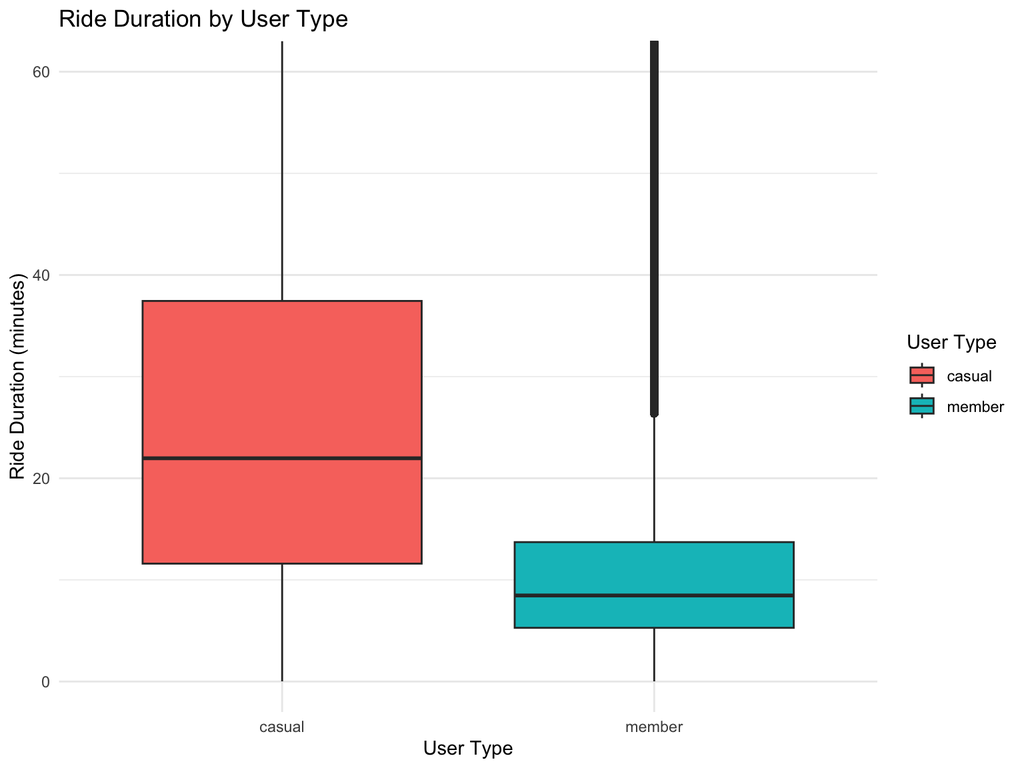

```r
ggplot(analysis_df, aes(x = member_casual, y = ride_length, fill = member_casual)) +
  geom_boxplot() +
  coord_cartesian(ylim = c(0, 60)) +
  labs(
    title = "Ride Duration by User Type",
    x = "User Type",
    y = "Ride Duration (minutes)",
    fill = "User Type"
  ) +
  theme_minimal()
```

## 5. Analyze Phase – Weekday Usage

### Prepare 2020 Data

```r
analysis_2020 <- analysis_df %>% filter(year == 2020) %>%
  mutate(day_of_week = factor(weekdays(started_at),
                             levels = c("Monday", "Tuesday", "Wednesday",
                                        "Thursday", "Friday", "Saturday", "Sunday")))
```

### Weekday Usage Summary

```r
day_usage <- analysis_2020 %>%
  group_by(member_casual, day_of_week) %>%
  summarise(total_rides = n()) %>%
  arrange(member_casual, desc(total_rides))
day_usage
```

```
## # A tibble: 14 × 3
## # Groups:   member_casual [2]
##    member_casual day_of_week total_rides
##    <chr>         <fct>             <int>
##  1 casual        Sunday            14820
##  2 casual        Saturday           7445
##  3 casual        Wednesday          5846
##  4 casual        Tuesday            5225
##  5 casual        Friday             5103
##  6 casual        Thursday           4819
##  7 casual        Monday             4785
##  8 member        Tuesday           69692
##  9 member        Wednesday         63969
## 10 member        Monday            61916
## 11 member        Thursday          61236
## 12 member        Friday            55477
## 13 member        Sunday            35959
## 14 member        Saturday          30095
```

### Plot Weekday Usage

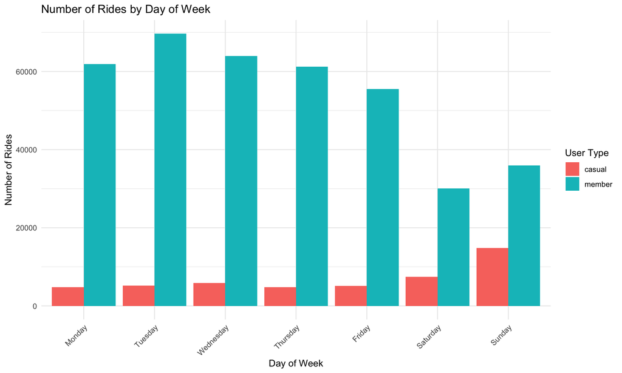

```r
ggplot(analysis_2020, aes(x = day_of_week, fill = member_casual)) +
  geom_bar(position = "dodge") +
  labs(
    title = "Number of Rides by Day of Week",
    x = "Day of Week",
    y = "Number of Rides",
    fill = "User Type"
  ) +
  theme_minimal() +
  theme(axis.text.x = element_text(angle = 45, hjust = 1))
```

## 6. Share Phase – Summary of Insights

Based on the analysis, we identified clear differences between annual members and casual riders:

- **Ride Duration:**
  - Casual riders have significantly longer average ride durations compared to annual members.
  - Members tend to use the bikes for shorter, more routine trips (e.g., commuting), while casual users likely use them for leisure.
- **Weekday vs Weekend Usage:**
  - Members have higher usage during weekdays, consistent with work commutes.
  - Casual riders show more activity on weekends, suggesting recreational use.
- **Overall Ride Counts:**
  - Annual members take more rides overall, but casual riders contribute a substantial portion during weekends and holidays.

These insights highlight key behavioral differences between the two user groups.

## 7. Act Phase – Recommendations

Based on our findings, we recommend the following strategies to help convert casual riders into annual members:

1. **Weekend Membership Promotions:**
   - Offer discounted or trial weekend memberships to attract casual riders who are already active on weekends.
2. **Leisure-Focused Membership Packages:**
   - Create membership tiers focused on leisure use, with benefits like free guest passes or discounts at partner attractions.
3. **Targeted Digital Marketing:**
   - Use social media and email campaigns to reach casual users, emphasizing the cost savings and added convenience of membership.
4. **In-App Nudges:**
   - Add prompts in the app after 2–3 casual rides suggesting annual membership with clear cost comparisons.

These actions can help Cyclistic capitalize on casual rider behavior and grow its member base.